# Subproductos del hierro y el acero

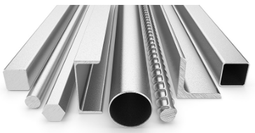

Perfiles de acero. Fuente: serveiestacio.com

## Introducción

Vimos que la transformación del hierro en acero comienza en el **alto horno** en donde se produce un **hierro líquido** con mucho carbono (alrededor de 4%) llamado arrabio. Es muy duro y frágil, imposible de forjar o laminar, pero es el punto de partida para todo lo demás. Luego del alto horno el arrabio puede seguir normalmente dos caminos: la fundición y la acería (este último ya lo vimos pero lo vamos a repasar)

## Primer camino: la fundición

Una parte del arrabio se usa directamente para fabricar **fundiciones**. Al vaciarlo en moldes y dejarlo solidificar, se obtiene el **metal fundido** ya con la forma de la pieza final.

En las fundiciones, controlando ciertos factores, se puede lograr que el **carbono** del arrabio se presente de dos maneras al solidificarse:

1. **Combinado con el hierro**, formando **cementita (Fe₃C)** → el material resulta muy duro y frágil, con pocas aplicaciones mecánicas.
2. **Libre, separado del hierro**, formando **grafito** → el material es más blando y fácil de mecanizar.

En las fundiciones con grafito, además puede controlarse la forma en que este cristaliza, obteniendo dos tipos principales:

- **Fundición gris** (el grafito forma láminas):
  - Frágil pero fácil de mecanizar.
  - Ejemplos: bloques de motor, bancadas de máquinas.
- **Fundición nodular** (el grafito forma esferas):
  - Más resistente y tenaz.
  - Ejemplos: engranajes grandes, componentes de maquinaria agrícola y automotriz sometidos a carga y golpes.

Estas piezas **no se laminan**, se **obtienen por moldeo**.

## Segundo camino: la acería

La mayor parte del arrabio se envía a la **acería**, donde se **refina** para eliminar parte del carbono y las impurezas.  
Mediante procesos de reducción del carbono en el **convertidor LD** o en el **horno eléctrico**, el hierro se transforma en **acero líquido**: más limpio, más maleable y adaptable a muchas necesidades.  
De allí, el acero se solidifica en lingotes o en barras largas, que luego se envían a los trenes de laminación para obtener perfiles, chapas o barras terminadas.

## Los trenes de laminación: dando forma al acero

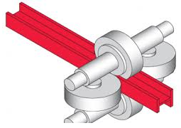

Laminación de perfiles. Fuente: cmrp.com

Los bloques de acero se calientan y pasan por enormes rodillos giratorios: los **trenes de laminación**.  
En ellos, el acero se aplana, estira y toma forma.  
Según el contenido de carbono, se obtienen productos distintos:

- **Acero de bajo carbono (hasta 0,25%)** → muy maleable; se lamina en **chapas, planchuelas, perfiles estructurales y tubos** (ej. SAE 1010 o 1020).
- **Acero de medio carbono (0,30–0,60%)** → más resistente; se entrega en **barras redondas o cuadradas**, ideales para ejes, pasadores o piezas mecanizadas (ej. SAE 1045).
- **Acero de alto carbono (más de 0,60%)** → muy duro; se entrega en **barras o alambres (alambrón)** para resortes, herramientas y cables.

## El envejecimiento del acero: oxidación y corrosión

El acero, al estar expuesto al aire y la humedad, tiende a degradarse por oxidación. Cuando esta oxidación ocurre en presencia de agua o sales, se transforma en corrosión, que es un hidróxido u óxido hidratado de hierro, conocido como **herrumbre** o **óxido rojo**, que es poroso y no protege: deja pasar el aire y el agua, permitiendo que la corrosión continúe.

En cambio, si el acero se oxida en ambientes secos o a alta temperatura, se forma una capa de óxido seca, más compacta y, a veces, protectora.

Por eso, la corrosión es una forma particular de oxidación destructiva, mientras que otras oxidaciones pueden no dañar el metal o incluso protegerlo parcialmente.